# PRactice 4

Michael Toledano

2/19/2022

# Question 1

### a)

Create a function that take a variable called `grade` which represents a score between 0 and 100 and outputs a letter grade. Here we define an `A` as 90 or above, `B` as 80 or above, `C` as 70 or above, `D` as 60 or above, and `F` as below 60. Test you function at least twice and show the results.

```r
grade_calculator = function(grade) {
  if(grade >= 90){
    return("A")
    }
  if(grade >= 80){
    return("B")
    }
  if(grade >= 70){
    return("C")
    }
  if(grade >= 60){
    return("D")
    }
  if(grade < 60) {
    return("F")
  }
}

grade_calculator(99)
```

```
## [1] "A"
```

```r
grade_calculator(67)
```

```
## [1] "D"
```

### b)

After a particularly rough semester, you are interested in finding the minimum grade you must receive on the final to pass class. The class points are broken down into 70% homework and 30% final exam.

Create a function that takes arguments `homework` which represents your homework average for the semester (0-100) and `final` which represents your desired score on the final (0-100) and returns a statement saying either “PASS” or “FAIL” using a C as a cutoff for passing.

```r
calc_final_grade <- function(homework, final) {
  grade = homework * 0.7 + final * 0.3
  if (grade >= 70){
    return("PASS")
    }
  else {
    return("FAIL")
  }
}
```

### c)

Assuming you averaged a 70 on the homework, what is the minimum final grade you must receive to pass the class? Use your function to guess and check what the minimum final grade you need.

```r
calc_final_grade(70, 65)
```

```
## [1] "FAIL"
```

```r
calc_final_grade(70, 68)
```

```
## [1] "FAIL"
```

```r
calc_final_grade(70, 69)
```

```
## [1] "FAIL"
```

```r
calc_final_grade(70, 70)
```

```
## [1] "PASS"
```

Answer:

The lowest grade to pass is a 70 on the final.

# Question 2

### a)

Create a function that takes argument `var` which represents a variable extracted from a tibble (a vector) and returns a 95% confidence interval for the sample mean of the variable only if the variable is numeric. Otherwise, notify the function user that the entry is non-numeric with a string that says “Input is non-numeric”. The equation for a 95% confidence interval is below:

$$\overline{x} \pm
z*\frac{s}{\sqrt{n}}$$

Where $\overline{x}$ is the mean, $z$ is the z-score, $s$ is the standard deviation, and $n$ is the number of observations.

```r
make_mean_ci <- function(var) {
  if(!is.numeric(var)){
    return("Non-numeric Entry")
  }
  mean_var = mean(var)
  sd_var = sd(var)
  n = length(var)
  upper_bound = mean_var + 1.96 * sd_var / sqrt(n)
  lower_bound = mean_var - 1.96 * sd_var / sqrt(n)
  return(c(lower_bound, upper_bound))
}
```

### b)

Test this function on the supplement and length variables from the tooth growth dataset in `ToothGrowth.csv`.

```r
tooth_growth <- read_csv("Homework 4 Files/data/ToothGrowth.csv")

# With pipe
tooth_growth %>%
  pull(Supplement) %>%
  make_mean_ci()
```

```
## [1] "Non-numeric Entry"
```

```r
tooth_growth %>%
  pull(Length) %>%
  make_mean_ci()
```

```
## [1] 16.87779 20.74888
```

# Question 3

### a)

Many datasets are created with missing values labeled as 999 or 9999. Create a function that takes in a value and if it is 999 or 9999 changes it to NA (integer). Test your function on x, y, and z created below.

```r
x <- 999
y <- 65
z <- 9999

fix_missing <- function(value){
  if(value == 999 | value == 9999){
    return(NA)
  }
  return(value)
}
```

```r
fix_missing(x)
```

```
## [1] NA
```

```r
fix_missing(y)
```

```
## [1] 65
```

```r
fix_missing(z)
```

```
## [1] NA
```

### b)

Similarly, some datasets will label missing values with two asterisks. Adapt your function so if the input is a character variable it will change all double asterisk signs to NA, and for numeric variables it changes 999 and 9999 to NA. Now, test the function on w, x, y, and z as created below. Explain why it works as it does with each test.

```r
fix_missing <- function(value){
  if(is.numeric(value)){
    if(value == 999 | value == 9999){
      return(NA)
    }
    return(value)
  }
  if(is.character(value)){
    if(value == "**"){
      return(NA)
    }
    return(value)
  }
}


w <- "999"
x <- "char"
y <- "**"
z <- 88
```

```r
fix_missing(w)
```

```
## [1] "999"
```

```r
fix_missing(x)
```

```
## [1] "char"
```

```r
fix_missing(y)
```

```
## [1] NA
```

```r
fix_missing(z)
```

```
## [1] 88
```

Answer:

w - Since the variable is stored as a character variable and isn’t ** the function returns the original value.

x - Since the variable is a character variable and isn’t ** the function returns the original value.

y - Since the variable is a character variable and is ** the function returns NA.

z - Since the variable is numeric and isn’t 999 or 9999, the function returns the original value.

### c)

Lastly, to improve your function, ensure it returns appropriate error messages. If the object given is a data frame, rather than an atomic object, have it inform the user (use `is.data.frame()` to test for whether the object is a data frame). Test your updated function with the objects a, b, and c created below.

```r
fix_missing <- function(value){
  if(is.data.frame(value)){
    return("Error: input is a dataframe")
  }
  if(is.numeric(value)){
    if(value == 999 | value == 9999){
      return(NA)
    }
    return(value)
  }
  if(is.character(value)){
    if(value == "**"){
      return(NA)
    }
    return(value)
  }
}

a <- 6
b <- "red"
c <- tibble(color = c("red", "green", "blue", "**"), number = c(5, 10, 999, 12))

fix_missing(a)
```

```
## [1] 6
```

```r
fix_missing(b)
```

```
## [1] "red"
```

```r
fix_missing(c)
```

```
## [1] "Error: input is a dataframe"
```

# Question 4

### a)

A collaborator has given you four data sets to analyze (the code below reads in the data). Unfortunately, all four are messy and need cleaning. Rather than clean each individually, write a function which cleans the dataset given as needed. Specifically, your function should:

1. clean variable names (think of the `clean_names()` function)
2. remove the extra row
3. remove the notes variable
4. drop any rows with missing values (check out the `drop_na()` function)
5. remove entries with negative heights, lengths, or weights
6. convert the height, weight, and length variables to numeric
7. create a new variable called `new_var` which is the product of weight times height times length

```r
table1 <- read_excel("Homework 4 Files/data/table1.xlsx")
table2 <- read_excel("Homework 4 Files/data/table2.xlsx")
table3 <- read_excel("Homework 4 Files/data/table3.xlsx")
table4 <- read_excel("Homework 4 Files/data/table4.xlsx")

clean_data <- function(data){
  data = data %>%
    clean_names() %>%
    filter(table_id != "extra") %>%
    select(-notes) %>%
    drop_na() %>%
    filter(height_in_inches > 0 & weight_in_pounds > 0 & length > 0) %>%
    mutate(
      height_in_inches = as.numeric(height_in_inches),
      weight_in_pounds = as.numeric(weight_in_pounds),
      length = as.numeric(length),
      new_var = height_in_inches * weight_in_pounds * length
    )
  return(data)
}

cdata1 <- clean_data(table1)
cdata2 <- clean_data(table2)
cdata3 <- clean_data(table3)
cdata4 <- clean_data(table4)
```

### b)

Combine all 4 resulting datasets (using `bind_rows`) and print the resulting data below using kable.

```r
combined <- bind_rows(cdata1, cdata2, cdata3, cdata4)

kable(combined)
```

| table_id | height_in_inches | weight_in_pounds | length | name | new_var |
| --- | --- | --- | --- | --- | --- |
| 1 | 16 | 100 | 33 | blue coffee table | 52800 |
| 4 | 12 | 44 | 22 | red table | 11616 |
| 5 | 50 | 43 | 40 | desk | 86000 |
| 10 | 25 | 20 | 58 | wood table | 29000 |
| 17 | 18 | 30 | 80 | dinning table | 43200 |
| 18 | 22 | 15 | 80 | kids table | 26400 |
| 19 | 12 | 50 | 50 | long table | 30000 |
| 28 | 36 | 70 | 50 | metal rim | 126000 |
| 29 | 24 | 40 | 80 | desk | 76800 |

# Question 5

Your colleague has shared a dataset for a medium sized depression study. This study had two active treatments and a control group over 10 weeks. The main outcome of interest was the PHQ-9 sum score, which can range from 0-27. The data is stored in the `depression_study.csv` file.

### a)

During a meeting with your colleague they sketch out a graph they would like you to make for an upcoming poster session. Your colleague does not know exactly what the data will look like, but has a general idea of the graph they want. The picture they sketched, along with some notes, is included below in the `graph-sketch.jpg` file. Take a look at it by clicking on it in the file explorer in the lower right hand section of RStudio.

Important things to notice:* (1) Your colleague is interested in mean PHQ-9 by treatment by day. (2) Your colleague wants the x and y axis to have specific ranges, tick marks, and labels. (3) Your colleague wants the colors of the three treatments to be different. (4) Your colleague wants the points that represent the three treatments to be different as well – squares, circles, and triangles. (5) Your colleague wants the legend below the plot.

Use what you have learned about data manipulation and plotting to try to create a plot that matches their sketch to the best of your ability. It’s okay if it isn’t perfect – but try your best to match what it looks like they wanted.

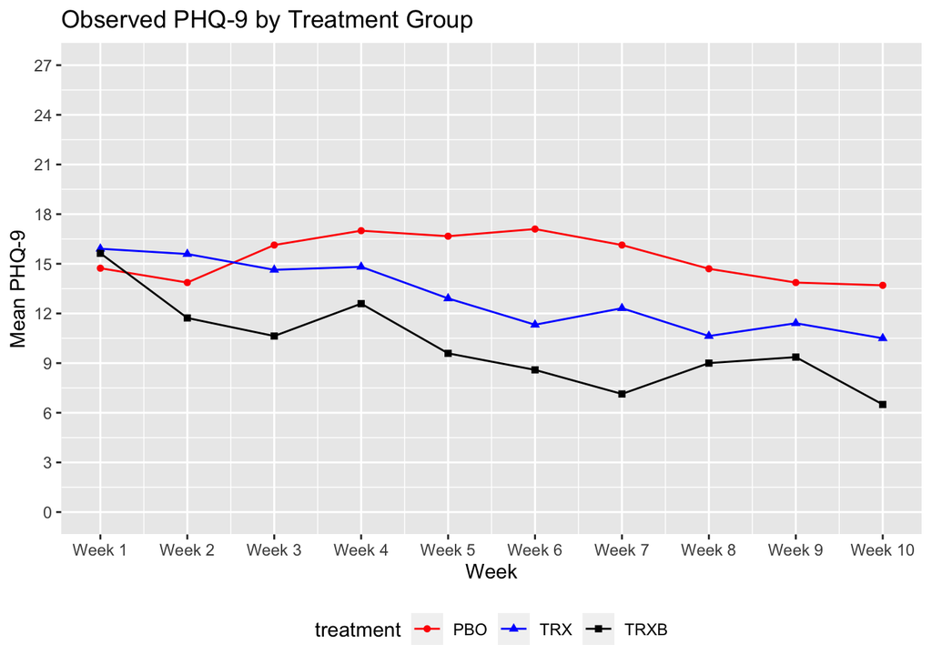

```r
depression_dat <- read_csv("Homework 4 Files/data/depression_study.csv")

depression_graph_df <- depression_dat %>%
  group_by(week, treatment) %>%
  summarize(mean_phq9 = mean(phq9))

ggplot(data = depression_graph_df) +
  geom_point(aes(x = week, y = mean_phq9, shape = treatment, color = treatment)) +
  geom_line(aes(x = week, y = mean_phq9, color = treatment)) +
  theme(legend.position = "bottom") +
  scale_x_continuous(breaks = 1:10, labels = paste("Week", 1:10)) +
  scale_y_continuous(limits = c(0, 27), breaks = seq(from = 0, to = 27, by = 3), labels = seq(from = 0, to = 27, by = 3)) +
  labs(title = "Observed PHQ-9 by Treatment Group",
       x = "Week", y = "Mean PHQ-9") +
  scale_color_manual(values = c("pbo" = "red", "trx_a" = "blue",
                     "trx_b" = "black"), labels = c("pbo" = "PBO",
                                                    "trx_a" = "TRX",
                                                    "trx_b" = "TRXB")) +
  scale_shape_discrete(labels = c("pbo" = "PBO","trx_a" = "TRX",
                                                    "trx_b" = "TRXB"))
```

# Question 6

In lecture and in this week’s R videos we have talked about power and how to calculate and visualize it using simulations.

Imagine we are studying a certain biomarker whose mean in most populations is 126 units. This biomarker is normally distributed with a variance of 144 units. We have the opportunity to test a particular subpopulation of interest to see if they differ in this biomarker, and for our tests we have access to a sample size of 25 individuals. We expect that this population will have a mean biomarker level of 132 units.

Follow the steps below to calculate the power we would have in this scenario.

### a)

Simulate 100,000 observations using the null hypothesis distribution using the `rnorm()` function.

```r
null_samples <- rnorm(100000, mean = 0, sd = 1)
```

### b)

Determine the rejection region for a two-sided hypothesis test at a level of significance of 5%.

```r
critical_value <- 1.96
```

### c)

Create a new categorical variable `rejection_region` based on whether a null hypothesis simulated observation is inside of the rejection region. What proportion of simulated observations using the null hypothesis fall inside the rejection region? You should report this proportion using in-line R code. Give a precise number (up to 5 decimal places). Why is it not exactly 5%?

```r
null_tibble <- tibble(obs = null_samples, scenario = "Null Hypothesis")

null_rej <- null_tibble %>%
  mutate(rejection_region = if_else(obs < -1.96 | obs > 1.96, "rejection", "non-rejection"))

prop_rej_null <- null_rej %>%
  group_by(rejection_region) %>%
  summarize(n = n()) %>%
  mutate(proportion = n/sum(n))

rej_prop <- prop_rej_null %>%
  filter(rejection_region == "rejection") %>%
  pull(proportion) %>%
  round(5)
```

Answer:

The proportion of observations that fall within the rejection region is 0.05029. This is not exactly 5% because we are performing a simulation – but it is very close

### d)

Compute the z-score for our alternative hypothesis, the case where the sub-population has a mean biomarker level of 132 units. You can find the formula for the z-score in this week’s slides.

```r
alt_mean <- 132
null_mean <- 126

# SD is square root of variance
sd <- sqrt(144)

n <- 25

z_score <- (alt_mean - null_mean)/(sd/sqrt(n))

z_score
```

```
## [1] 2.5
```

### e)

Next, simulate 100,000 observations using the the alternative hypothesis using the `rnorm()` function.

```r
alt_samples <- rnorm(100000, mean = 2.5, sd = 1)
```

### f)

Create a new categorical variable `rejection_region` based on whether an alternative hypothesis simulated observation is inside of the rejection region. What proportion of simulated observations using the alternative hypothesis fall inside the rejection region (this is the definition of power)? You should report this proportion using in-line R code. Give a precise response (up to 5 decimal places).

```r
alt_tibble <- tibble(obs = alt_samples, scenario = "Alternative Hypothesis")

alt_rej <- alt_tibble %>%
  mutate(rejection_region = if_else(obs < -1.96 | obs > 1.96, "rejection", "non-rejection"))

alt_props <- alt_rej %>%
  group_by(rejection_region) %>%
  summarize(n = n()) %>%
  mutate(proportion = n/sum(n))

power <- alt_props %>%
  filter(rejection_region == "rejection") %>%
  pull(proportion) %>%
  round(5)
```

Answer:

The proportion of simulated observations falling in the rejection region if the alternative hypothesis were true (or the power) is 0.70649.

### f)

Combine your alternative hypothesis simulated data with null hypothesis data into one dataset using `bind_rows()`. Create a graph that displays the distributions under the null and alternative hypotheses that is just like the graph presented in lecture and the R videos.

*Key components your graph must have:* (1) Custom colors for the rejection and non-rejection regions (you can choose your own if you like). (2) The graph must have facets for null hypothesis and alternative hypothesis observations. (3) The x-axis, y-axis, and legend must be properly labeled. (4) Your graph needs to have two vertical dashed lines that mark the boundary between rejection and non-rejection regions.

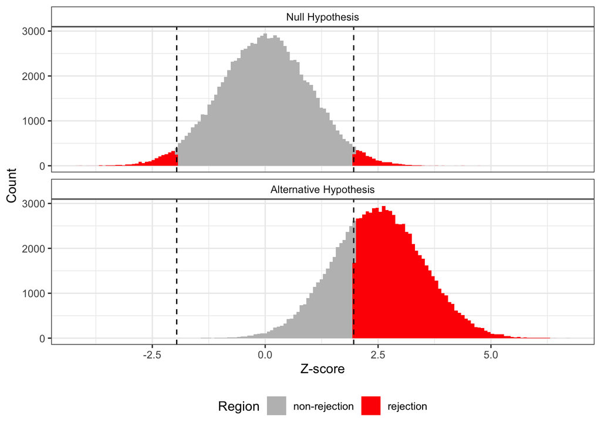

```r
combined_tibble <- bind_rows(null_rej, alt_rej) %>%
  mutate(scenario_fac = factor(scenario, levels = c("Null Hypothesis", "Alternative Hypothesis")))

ggplot(data = combined_tibble) +
  geom_histogram(aes(x = obs, fill = rejection_region), bins = 150) +
  geom_vline(aes(xintercept = 1.96), linetype = "dashed") +
  geom_vline(aes(xintercept = -1.96), linetype = "dashed") +
  facet_wrap(~scenario_fac, ncol = 1) +
  scale_fill_manual(values = c("rejection" = "red", "non-rejection" = "grey")) +
  theme_bw() +
  labs(x = "Z-score", y = "Count", fill = "Region") +
  theme(strip.background = element_rect(fill = "white"),
        legend.position = "bottom")
```

### g)

Answer:

This study does not achieve 80% power. The one feasible aspect of the study we might be able to change is the sample size, by increasing the sample size we increase our power.